# Lecture 11

March 16, 2016

## Notecard Question 1

What do you think is the ratio of mean heights of men and mean heights of women in the San Francisco?

## Paired Data

Say we have the price of about 70 textbooks at the UCLA bookstore vs Amazon. There is an obvious pairing between observations in the two samples.

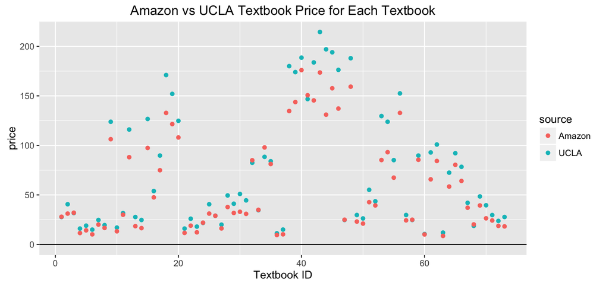

## Paired Data

Instead of focusing on \(\mu_{\text{amazon}} - \mu_{\text{UCLA}}\), focus on \(\mu_{\text{diff}}\).

i.e. not the **difference in means**, but the **mean difference**:

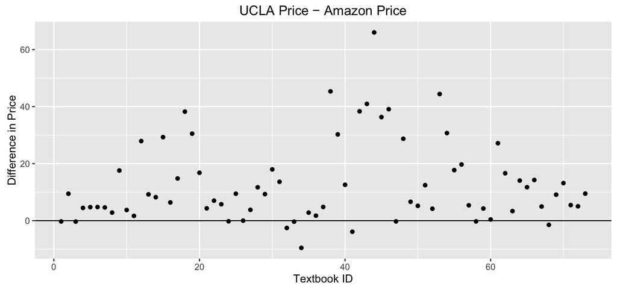

## Today's Population

We consider 59K users who were

- members of OkCupid on 2012/06/26
- within 25 miles of SF
- online in the last year
- have at least one photo

Their public profiles were scraped on 2012/06/30.

Thank you to OkCupid CEO Christian Rudder for giving permission to use this data.

## Data

5 randomly chosen people:

| sex | height |
| --- | --- |
| m | 64 |
| m | 71 |
| m | 69 |
| m | 78 |
| m | 70 |

## Histogram

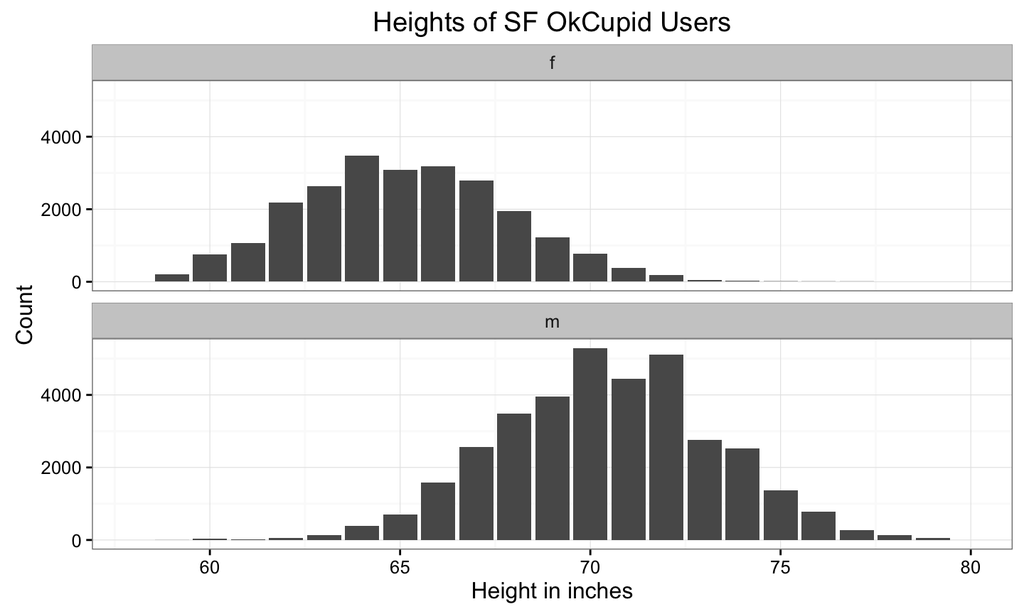

## Parameter of Interest

By what factor are men on average taller than women? i.e.

\[ \frac{\mu_M}{\mu_F} \]

Technically, we know the entire population, so we can compute this value exactly i.e. we don't need statistics.

Let's pretend however, that we only have a random sample of 10% of these users.

## Bootstrap Algorithm

```r
males <- subset(sample, select = height, subset = sex=="m", drop = T)
females <- subset(sample, select = height, subset = sex=="f", drop = T)

N <- 10^4
boot_ratio <- rep(0, N)

for(i in 1:N){
  boot_males <- sample(males, length(males), replace=TRUE)
  boot_females <- sample(females, length(females), replace=TRUE)

  boot_ratio[i] <- mean(boot_males)/mean(boot_females)
}
```

## Bootstrap Distribution

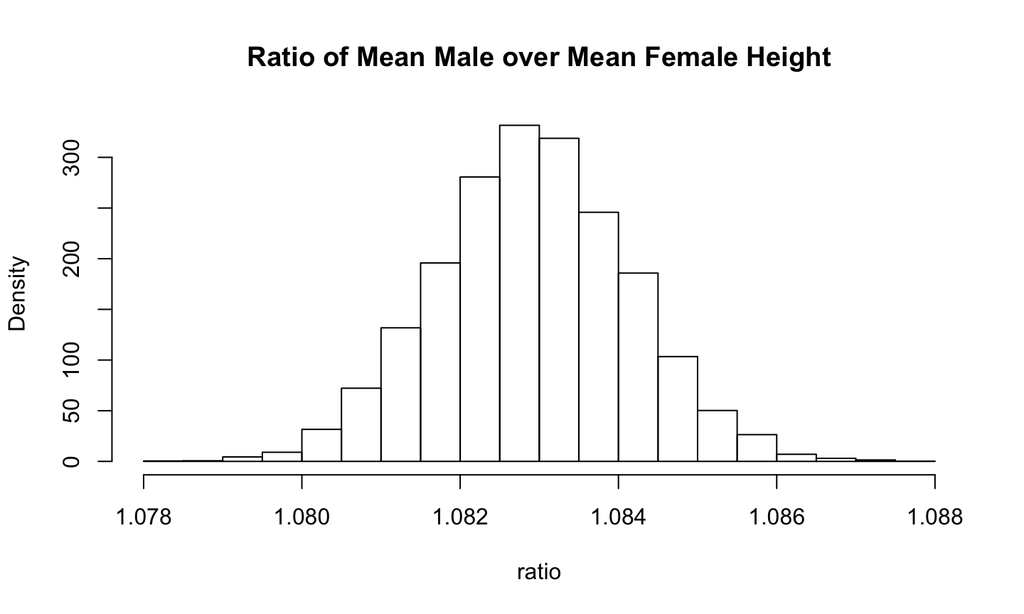

## Bootstrap Percentile Interval

We compute the percentile interval using the `quantile()` function

```r
quantile(boot_ratio, probs = c(0.025, 0.975))
```

```
##     2.5%    97.5%
## 1.080554 1.085324
```

## Bootstrap Percentile Interval

We plot the CI with dashed lines:

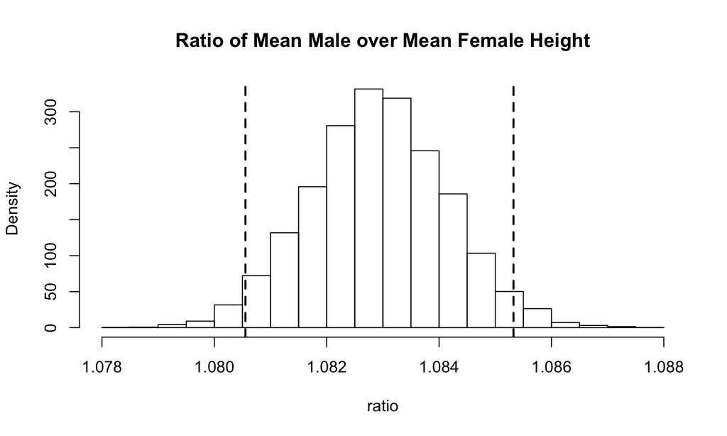

## Bootstrap Percentile Interval

The true population ratio is 1.082. In this case, the CI captured it.

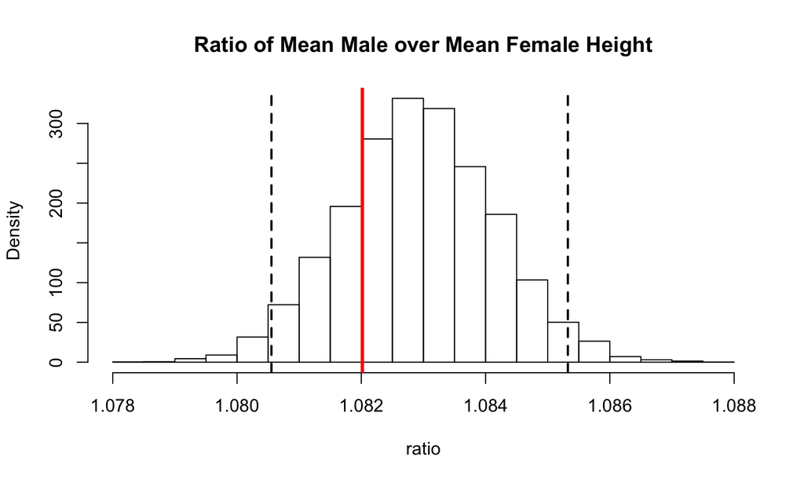

## Interpretation of Confidence Intervals

If we were to repeat this whole procedure, say, 100 times:

1. Take a sample of 10% of the population
2. Compute the bootstrap CI

Then we expect 95 of the resulting CI's to capture the true value.

## Interpretation of Confidence Intervals

The true ratio \(\mu_M/\mu_F = 1.082\) is the dashed black line.

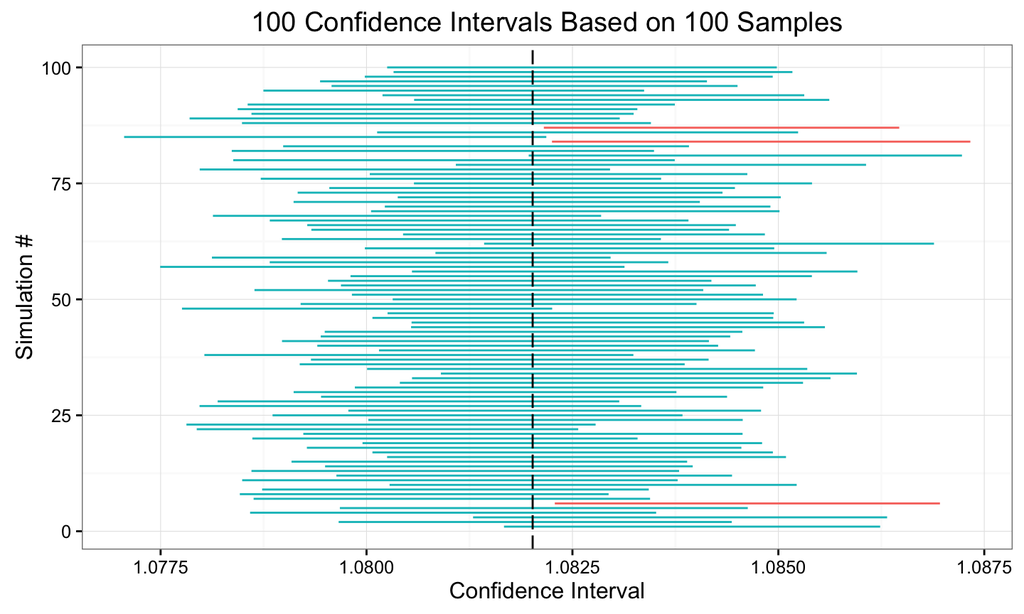

## In Practice

Much like our sampling distribution examples, this was a **theoretical/rhetorical** exercise. In practice

- We don't
  - Construct more than one CI
  - Do this if we already know the true population parameter
- We do
  - Compute one CI based on one sample. This is our best guess: **We are 95% "confident" the value lies in the CI.**

## Monte Carlo Methods

One way to approximate \(\int f(x) dx\) is to multiply

- the proportion of random points that fall below \(f(x)\) by
- the area of the box

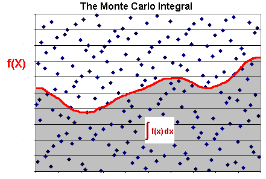

## Likelihood Function for \(\widehat{p}=0.3\)

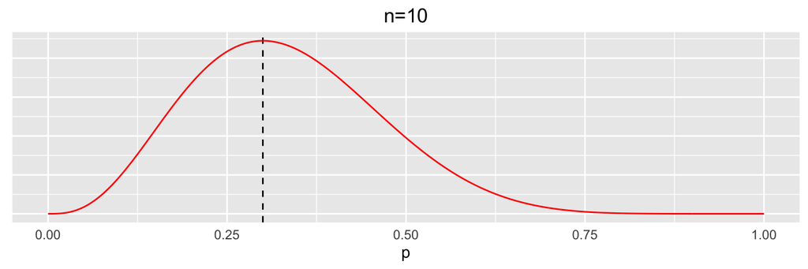

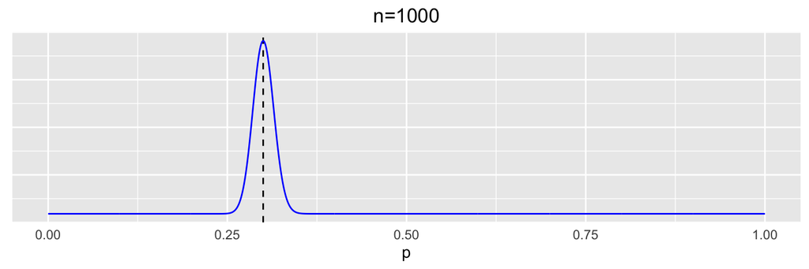